# Cleaning the dataset

```r
library("tidyverse")
```

[output not shown]

```r
library("here")
```

```
here() starts at /net/pupil1/home/people/s233426/22160/r_for_bio_data_science/projects/group_09_project
```

```
here() starts at /home/marco/group_09_project
```

```r
library("viridis")
source("99_proj_func.R")
```

Building on top of the consideration made, we perform the cleaning. Here we had a major decision point about the direction the analysis will take.

```r
data_path <- here("data/03_dat_selected.csv")
dataset <- read_csv(data_path,
                    na = c("nd", "-", "na"),
                    show_col_types = FALSE)
```

The first thing we do is unify the original datasets that are splitted (t2d is splitted in t2dmeta_long / short, and the hmp is splitted in hmp/hmpii).

```r
dataset <- dataset |>
  mutate(dataset_name = case_when(
    dataset_name == "t2dmeta_long" ~  "t2d",
    dataset_name == "t2dmeta_short" ~ "t2d",
    dataset_name == "hmpii" ~ "hmp",
    TRUE ~ dataset_name))
```

The dataset is divided in metadata and microorganism relative abundances. We divide the two dataset to facilitate cleaning:

```r
metadata <- dataset |>
  select(-starts_with("k__"))

dim_desc(metadata)
```

```
[1] "[2,243 x 211]"
```

The wide variety of studies from which the data comes from results in a large number of study-specific metadata. This can be observed by plotting the amount of NA present in each of these.

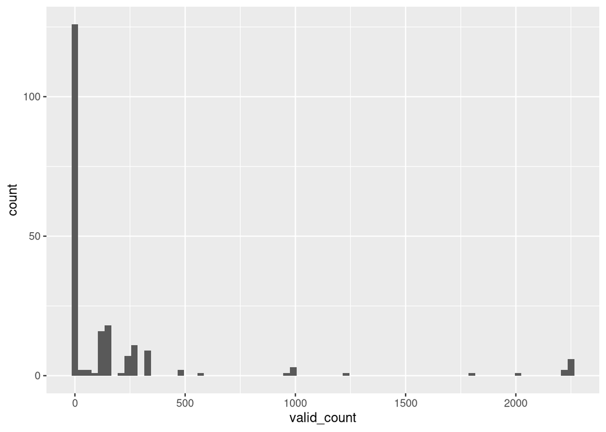

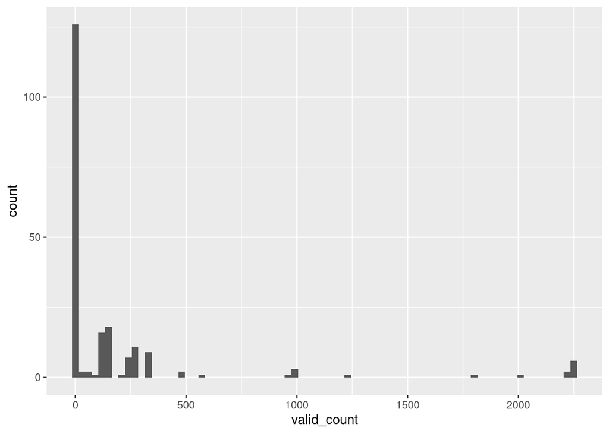

```r
valid_counts <- metadata |>
summarise(across(everything(),
                 ~sum(!is.na(.))),
          ) |>
pivot_longer(everything(),
             names_to = "column_name",
             values_to = "valid_count")
valid_counts |>
  ggplot(aes(x=valid_count)) +
  geom_histogram(binwidth = 30)
```

We can see that there are many columns with a lot / or even only missing values.

Many of these columns are dataset-specific, we can show that by plotting the columns group by the number of valid data and looking which dataset contain those valid datapoints.

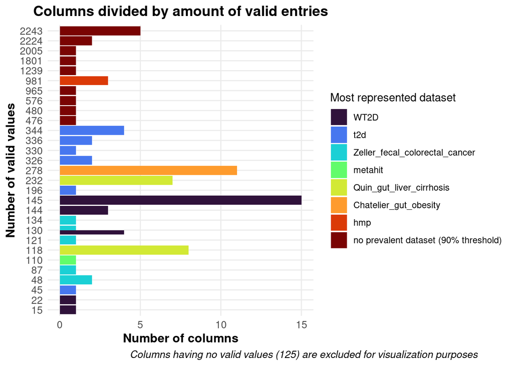

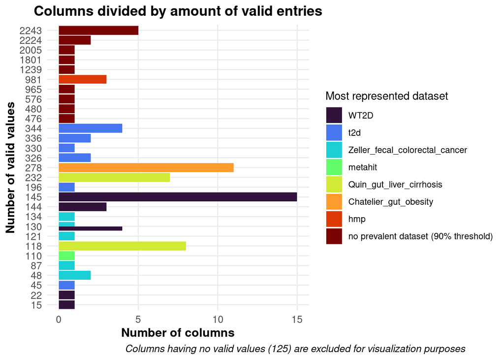

```r
# For each column get the TOTAL number of non-NAs values
valid_values_count <- metadata |>
  select(-dataset_name) |>  # we obviusly don't care about the data_set name column
  summarise(across(everything(),
                   ~ sum(!is.na(.)))) |>
  pivot_longer(cols = everything(),
               names_to = "column",
               values_to = "valid_count")

# Calculate the number of valid datapoint that each dataset has in each column
valid_values_by_dataset <- metadata |>
  group_by(dataset_name) |>
  summarise(across(everything(),
                   ~ sum(!is.na(.)),
                   .names = "{col}")) |>
  pivot_longer(cols = -dataset_name,
               names_to = "column",
               values_to = "dataset_valid_count")

# Calculate the proportion of valid datapoint that each dataset has in each column
valid_proportions <- valid_values_by_dataset |>
  left_join(valid_values_count, by = "column") |>
  mutate(proportion = ifelse(valid_count == 0, 0, dataset_valid_count / valid_count))

# for each column select the most represented dataset (% > 90%, otherwise) if there is none the the column is considered mixed
most_represented_dataset <- valid_proportions |>
  group_by(column) |>
  arrange(desc(proportion))  |>
  slice(1) |>
  ungroup() |>
  mutate(most_representative_dataset = ifelse(proportion > 0.9, dataset_name, "no prevalent dataset (90% threshold)")) |>
  mutate(proportion = ifelse(proportion > 0.9, proportion, NA))|>
  select(-dataset_name)

# Divide the columns based on the amount of NAs they contain
valid_count_distribution <- most_represented_dataset |>
  group_by(valid_count,
           most_representative_dataset) |>
  summarise(count = n(),
            .groups = "drop") |>
  mutate(most_representative_dataset = factor(
    most_representative_dataset,
    levels = c(setdiff(unique(most_representative_dataset),
                       "no prevalent dataset (90% threshold)"),
               "no prevalent dataset (90% threshold)")
  ))

#FINALLY!!! We can plot the column distribution
valid_entries_per_column_plot <- valid_count_distribution |>
  filter(valid_count != 0) |>
ggplot(aes(x = as.factor(valid_count), y = count, fill = most_representative_dataset)) +
  geom_bar(stat = "identity", position = "dodge") +
  labs(
    title = "Columns divided by amount of valid entries",
    x = "Number of valid values",
    y = "Number of columns",
    fill = "Most represented dataset",
    caption = "Columns having no valid values (125) are excluded for visualization purposes",
  ) +
  scale_fill_viridis(discrete = TRUE, option = "H") +
  theme_minimal() +
  theme(
    plot.title = element_text(face = "bold", size = 14, hjust = 0.5),
    axis.text.x = element_text(size = 10),
    axis.text.y = element_text(size = 10),
    axis.title.x = element_text(face = "bold", size = 12),
    axis.title.y = element_text(face = "bold", size = 12),
    plot.caption = element_text(face = "italic", size = 10, hjust = -1),
    panel.grid.minor.x = element_blank()) +
  coord_flip()

save_plot_custom(plot = valid_entries_per_column_plot,
                 filename = "04_valid_entries.jpg")
valid_entries_per_column_plot
```

The columns having only 278 non-NAs values, are columns specific of the “obesity” dataset.

The columns having only 232 non-NAs values, are columns specific of the “Quin_gut_liver_cirrhosis” dataset.

The columns having only 145 non-NAs values, are columns specific of the “WT2D” dataset.

The columns having only 110 non-NAs values, are columns specific of the “metahit” dataset.

The columns having only 981 non-NAs values, are columns specific of the “hmp” dataset.

These columns are can be really important for analysis of single datasets, so we have to decide what to do them.

### Decision point

Because of what was said before there are two possible approaches:

1. choose only a single dataset and focus the analysis on that one. This allows us to perform more significant analysis on the metadata and also makes the abundance data smaller, thus making it easier to work with it.
2. keep all the datasets and only maintain the columns which are significant for most of them. This makes it difficult to perform significant analysis on the metadata as not many information are left. On the other hand we have much more data to study in terms of microbiota.

### Approach 1 - Focusing on WT2D

To the purpose of the project we decided that focusing our effort in the analysis of only a dataset was better. As it allows to better show what we have learned in the course. From the plot above we can see that the dataset having the largest amount of metadata columns (thus giving us many opportunity to do analysis) is the WT2D dataset ([original paper](https://doi.org/10.1038/nature12198)).

```r
metadata <- dataset |>
  filter(dataset_name == "WT2D") |>
  select(-starts_with("k__"))
```

We need to get rid of the columns containing to many missing values.

```r
valid_counts <- metadata |>
summarise(across(everything(), ~sum(!is.na(.)))) |>
pivot_longer(everything(), names_to = "column_name", values_to = "valid_count")
```

```r
to_remove <- valid_counts |>
  filter(valid_count < 140) |>
  pull(column_name)

metadata <- metadata |>
  select(-all_of(to_remove))
```

We remove columns having the same value for all rows as they do not provide any information.

```r
metadata <- metadata |>
  select(where(~ n_distinct(.) > 1))
```

```r
metadata |>
  mutate(redundant = sampleID == str_to_upper(subjectID)) |>
  select(redundant) |>
  unique()
```

```
# A tibble: 1 × 1
  redundant
  <lgl>
1 TRUE
```

```r
metadata <- metadata |>
  select(-subjectID)
```

We see that the `classification` column is just another way of classifying the `disease` column with:

- n (no disease) = ngt (normal glucose tolerance)
- impaired_glucose_tolerance = igt
- t2d = t2d (type 2 diabetes)

```r
metadata |>
  select(disease, classification)
```

```
# A tibble: 145 × 2
   disease                    classification
   <chr>                      <chr>
 1 impaired_glucose_tolerance igt
 2 n                          ngt
 3 n                          ngt
 4 n                          ngt
 5 n                          ngt
 6 impaired_glucose_tolerance igt
 7 n                          ngt
 8 n                          ngt
 9 n                          ngt
10 impaired_glucose_tolerance igt
# ℹ 135 more rows
```

```r
metadata <- metadata |>
  select(-classification)
```

```r
relevent_rows <- metadata |>
  pull(sampleID)

abundance_data <- dataset |>
  filter(sampleID %in% relevent_rows) |>
  select(starts_with("k__"))
```

The only cleaning we can do on the abundances is that of removing columns that do not contain any data, i.e. columns the species of which is not present in any of the samples.

```r
abundance_data <- abundance_data |>
  select(where(~ sum(.x, na.rm = TRUE) != 0))
```

Lastly we merge the metadata with the abundance data. We can do it without checking the row correspondence, as we did not remove any row or alter their order during the cleaning.

```r
dataset <- metadata |>
  bind_cols(abundance_data)
```

```r
target_dir <- "../data"

# save the dataset in the data fodler
write_csv(dataset, str_c(target_dir, "/04_dat_clean.csv"))
```

### Approach 2 - We keep all datasets

Even though we are not going to follow this path we still provide an example of what the cleaning of this messier dataset could be done.

```r
dataset <- read_csv(data_path,
                    na = c("nd", "-", "na"),
                    show_col_types = FALSE)

metadata <- dataset |>
  select(-starts_with("k__"))
```

```r
valid_counts <- metadata |>
summarise(across(everything(),
                 ~sum(!is.na(.)))) |>
pivot_longer(everything(),
             names_to = "column_name",
             values_to = "valid_count")

to_remove <- valid_counts |>
  filter(valid_count < 0.7 * nrow(metadata)) |>
  pull(column_name)

metadata <- metadata |>
  select(-all_of(to_remove))
```

Even with these approach we still some columns with a varying number of non-NAs values.

```r
metadata |>
  filter(is.na(subjectID))
```

```
# A tibble: 19 × 10
   dataset_name sampleID subjectID bodysite disease gender country
   <chr>        <chr>    <chr>     <chr>    <chr>   <chr>  <chr>
 1 t2dmeta_long CON-024  <NA>      stool    <NA>    <NA>   <NA>
 2 t2dmeta_long CON-025  <NA>      stool    <NA>    <NA>   <NA>
 3 t2dmeta_long CON-030  <NA>      stool    <NA>    <NA>   <NA>
 4 t2dmeta_long CON-094  <NA>      stool    <NA>    <NA>   <NA>
 5 t2dmeta_long CON-100  <NA>      stool    <NA>    <NA>   <NA>
 6 t2dmeta_long CON-102  <NA>      stool    <NA>    <NA>   <NA>
 7 t2dmeta_long CON-103  <NA>      stool    <NA>    <NA>   <NA>
 8 t2dmeta_long CON-108  <NA>      stool    <NA>    <NA>   <NA>
 9 t2dmeta_long CON-109  <NA>      stool    <NA>    <NA>   <NA>
10 t2dmeta_long CON-110  <NA>      stool    <NA>    <NA>   <NA>
11 t2dmeta_long CON-111  <NA>      stool    <NA>    <NA>   <NA>
12 t2dmeta_long T2D-027  <NA>      stool    <NA>    <NA>   <NA>
13 t2dmeta_long T2D-032  <NA>      stool    <NA>    <NA>   <NA>
14 t2dmeta_long T2D-033  <NA>      stool    <NA>    <NA>   <NA>
15 t2dmeta_long T2D-034  <NA>      stool    <NA>    <NA>   <NA>
16 t2dmeta_long T2D-035  <NA>      stool    <NA>    <NA>   <NA>
17 t2dmeta_long T2D-037  <NA>      stool    <NA>    <NA>   <NA>
18 t2dmeta_long T2D-038  <NA>      stool    <NA>    <NA>   <NA>
19 t2dmeta_long T2D-061  <NA>      stool    <NA>    <NA>   <NA>
# ℹ 3 more variables: sequencing_technology <chr>, pubmedid <dbl>,
#   `#SampleID` <chr>
```

```r
metadata <- metadata |>
  filter(!is.na(subjectID))
```

We find that in the t2dmeta_long there are 19 samples are do not have any subjectID and are also missing a lot of metadata, this coincide with the hypothesis of these being the product of some error during the CSV production as by removing them we are able to perfectly match the number of samples expected for the t2d dataset (as found in during data selection).

Now we investigate the remaining data columns having NAs.

```r
metadata |>
  filter(is.na(gender))
```

```
# A tibble: 423 × 10
   dataset_name          sampleID subjectID bodysite disease gender country
   <chr>                 <chr>    <chr>     <chr>    <chr>   <chr>  <chr>
 1 Chatelier_gut_obesity MH0002   mh0002    stool    n       <NA>   denmark
 2 Chatelier_gut_obesity MH0003   mh0003    stool    obesity <NA>   denmark
 3 Chatelier_gut_obesity MH0006   mh0006    stool    leaness <NA>   denmark
 4 Chatelier_gut_obesity MH0009   mh0009    stool    n       <NA>   denmark
 5 Chatelier_gut_obesity MH0011   mh0011    stool    leaness <NA>   denmark
 6 Chatelier_gut_obesity MH0012   mh0012    stool    obesity <NA>   denmark
 7 Chatelier_gut_obesity MH0014   mh0014    stool    obesity <NA>   denmark
 8 Chatelier_gut_obesity MH0016   mh0016    stool    obesity <NA>   denmark
 9 Chatelier_gut_obesity MH0020   mh0020    stool    obesity <NA>   denmark
10 Chatelier_gut_obesity MH0021   mh0021    stool    n       <NA>   denmark
# ℹ 413 more rows
# ℹ 3 more variables: sequencing_technology <chr>, pubmedid <dbl>,
#   `#SampleID` <chr>
```

For `gender` we see that the samples not having a value belong to the WT2D or to the Chatelier_gut_obesity datasets. For the former we can verify by looking at the original paper that all the samples are taken from females, unfortunately the data is not recorded for the latter.

```r
metadata <- metadata |>
  mutate(gender = ifelse(dataset_name == "WT2D",
                         "female", gender))
```

Moving on to the country column

```r
metadata |>
  filter(is.na(country))
```

```
# A tibble: 219 × 10
   dataset_name sampleID subjectID bodysite         disease gender country
   <chr>        <chr>    <chr>     <chr>            <chr>   <chr>  <chr>
 1 hmpii        G18095   160603188 stool            n       male   <NA>
 2 hmpii        G18096   160380657 stool            n       male   <NA>
 3 hmpii        G18097   160380657 tongue_dorsum    n       male   <NA>
 4 hmpii        G18098   160380657 stool            n       male   <NA>
 5 hmpii        G18099   160319967 posterior_fornix n       female <NA>
 6 hmpii        G18100   160421117 stool            n       male   <NA>
 7 hmpii        G18101   160421117 stool            n       male   <NA>
 8 hmpii        G18102   160582958 stool            n       female <NA>
 9 hmpii        G18103   160178356 stool            n       male   <NA>
10 hmpii        G18104   160947100 stool            n       male   <NA>
# ℹ 209 more rows
# ℹ 3 more variables: sequencing_technology <chr>, pubmedid <dbl>,
#   `#SampleID` <chr>
```

We can see that is the hmpii dataset to not have the country registered, this can be solved as the HMP project only took into account samples from citizens of the US, as can be seen by the hmp dataset.

One last check allow us to see that the metadata column are now greatly reduced and only contain the columns having the accepted missing values.

```r
valid_counts <- metadata |>
summarise(across(everything(),
                 ~sum(!is.na(.)))) |>
pivot_longer(everything(), names_to = "column_name",
             values_to = "valid_count")

valid_counts |>
  filter(valid_count != nrow(metadata))
```

```
# A tibble: 2 × 2
  column_name valid_count
  <chr>             <int>
1 gender             1946
2 country            2005
```

The last cleaning we do is simply to remove data not useful for future analysis

```r
metadata <- metadata |>
  select(-sequencing_technology,
         -pubmedid,
         -`#SampleID`)
```

```r
# rm(list = ls() |>
#       keep(~ !is.function(get(.))) |>
#       discard(~ . %in% ls()))
```